# SI 618: Data Manipulation and Analysis

## Subplots (again)

In addition to the way we used subplots in the previous class, we can use the `.subplots()` function to generate mulitple plots within a figure. `subplots()` returns a set of axes on which we can make plots.

To demonstrate how this works, let's fill in just one of the subplots:

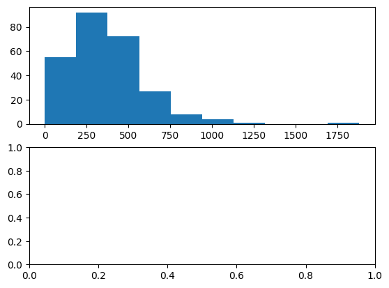

```python
f, (ax1, ax2) = plt.subplots(2)  # if only 1 argument, we assume it's the number of rows
ax1.hist(menu['Calories'])
plt.show()
```

Now let's fill in both subplots:

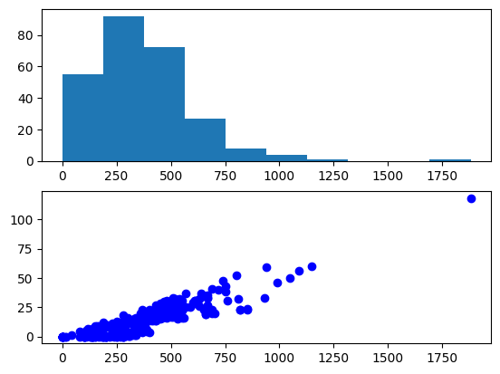

```python
f, (ax1, ax2) = plt.subplots(2)
ax1.hist(menu['Calories'])
ax2.plot(menu['Calories'], menu['Total Fat'], 'bo')
plt.show()
```

Now let's make a 2x2 layout of 4 plots. Note the structure of the return values from the subplots function:

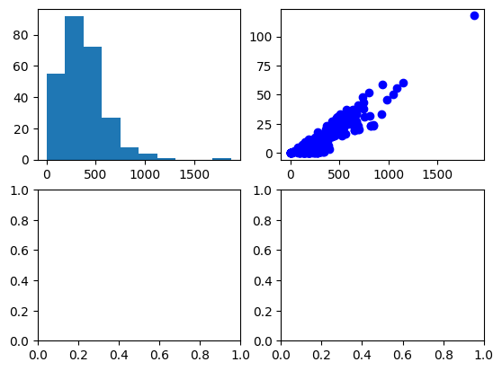

```python
f, ((ax1, ax2), (ax3, ax4)) = plt.subplots(2, 2)
ax1.hist(menu['Calories'])
ax2.plot(menu['Calories'], menu['Total Fat'], 'bo')
plt.show()
```

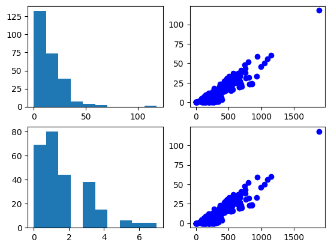

```python
f, ((ax1, ax2), (ax3, ax4)) = plt.subplots(2, 2)
ax1.hist(menu['Total Fat'])
ax2.plot(menu['Calories'], menu['Total Fat'], 'bo')
ax3.hist(menu['Dietary Fiber'])
ax4.plot(menu['Calories'], menu['Total Fat'], 'bo')
plt.show()
```

Alternatively, we can use the pandas-matplotlib integration. Note the use of the `ax=` keyword arg.

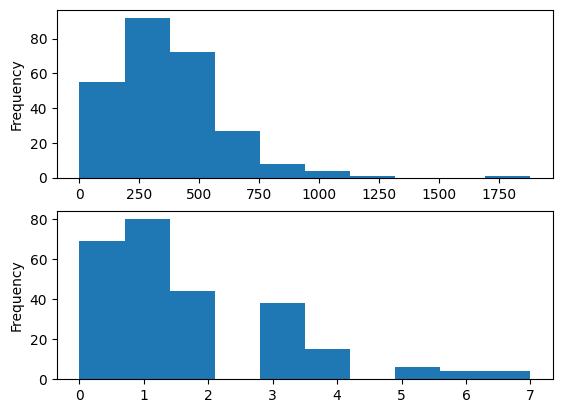

```python
f, (ax1, ax2) = plt.subplots(2)
menu['Calories'].plot(ax=ax1, kind='hist')
menu['Dietary Fiber'].plot(ax=ax2, kind='hist')
plt.show()
```

### Q8: Use subplots() to create a figure consisting of 4 plots.

They could be scatter plots, histograms, bar charts, pie plots, or any of the kinds (repeated here for your convenience):

```
kind :
- 'line' : line plot (default)
- 'bar' : vertical bar plot
- 'barh' : horizontal bar plot
- 'hist' : histogram
- 'box' : boxplot
- 'kde' : Kernel Density Estimation plot
- 'density' : same as 'kde'
- 'area' : area plot
- 'pie' : pie plot
```

```python
# (Optional)
```

# BREAK

## Simple (univariate) statistics

```python
# The weights of a herd of 80 cows
# Fixing random state for reproducibility
np.random.seed(618)

measures = (np.random.standard_normal(80)*150+1000).astype(int)
measures
```

```
array([1167, 1075,  893, 1066, 1025, 1084,  665, 1021, 1085,  886, 1161,
        959, 1008, 1004,  953, 1050, 1091,  857,  881,  891, 1048, 1213,
       1094, 1031,  935, 1014, 1054,  933, 1053, 1026,  844,  996, 1115,
        836,  884,  901,  801, 1226, 1091, 1448, 1119, 1215, 1199, 1030,
       1163,  987,  925, 1127, 1108, 1146, 1400,  984, 1035,  841, 1015,
        922, 1042, 1026,  888,  987,  933,  850, 1237, 1018,  955, 1308,
        817, 1146, 1022,  884, 1200,  979,  787, 1056, 1105, 1101, 1054,
       1285,  770,  710])
```

```python
# equivalently
# Fixing random state for reproducibility
np.random.seed(618)

measures = (np.random.normal(1000,150,80)).astype(int)
measures
```

```
array([1167, 1075,  893, 1066, 1025, 1084,  665, 1021, 1085,  886, 1161,
        959, 1008, 1004,  953, 1050, 1091,  857,  881,  891, 1048, 1213,
       1094, 1031,  935, 1014, 1054,  933, 1053, 1026,  844,  996, 1115,
        836,  884,  901,  801, 1226, 1091, 1448, 1119, 1215, 1199, 1030,
       1163,  987,  925, 1127, 1108, 1146, 1400,  984, 1035,  841, 1015,
        922, 1042, 1026,  888,  987,  933,  850, 1237, 1018,  955, 1308,
        817, 1146, 1022,  884, 1200,  979,  787, 1056, 1105, 1101, 1054,
       1285,  770,  710])
```

### Exercise 9:

Calculate some summary statistics for the `measures` variable you just created.

```python
pd.Series(measures).describe()
```

```
count      80.000000
mean     1021.762500
std       145.408481
min       665.000000
25%       924.250000
50%      1025.500000
75%      1102.000000
max      1448.000000
dtype: float64
```

## Visualizing data with Seaborn

- Visualization package built on top of matplotlib
- It's meant to make your life better
- Plays well with pandas, numpy, scipy, and statsmodels
- Many different visualization are included:
- Strip plots, Swarm plots, Violin plots
- Box plots
- Histograms

We need to import the package, and it's typically imported as sns:

```
import seaborn as sns
```

seaborn.pydata.org

## Seaborn versus Matplotlib

- Matplotlib
  - Low-level, basis for many packages
  - Painful to construct certain graphs
  - Not Pandas friendly
  - Not interactive
- Seaborn
  - Pandas friendlier
  - Great for some stats plots

```python
import seaborn as sns
```

## Strip Plot

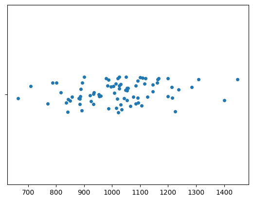

```python
sns.stripplot(x=measures)
```

## Swarm Plot

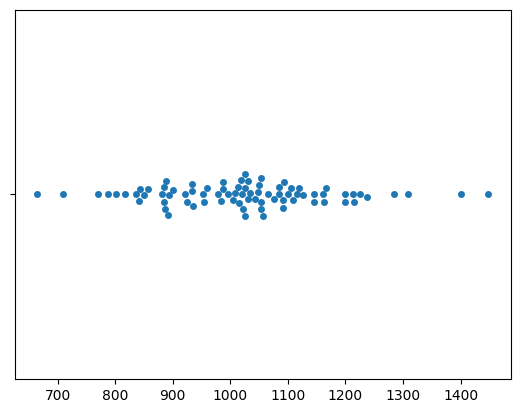

```python
sns.swarmplot(x=measures)
```

## Violin Plot

- If we have too much data

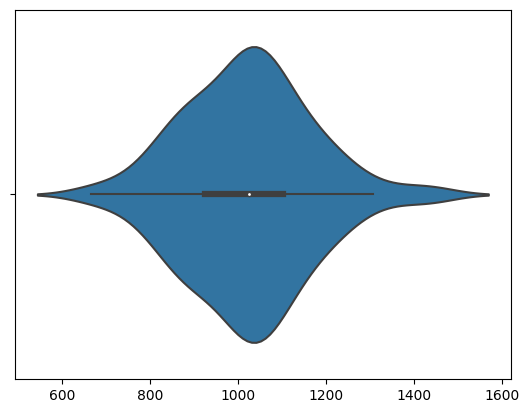

```python
sns.violinplot(x=measures)
```

## Box Plot

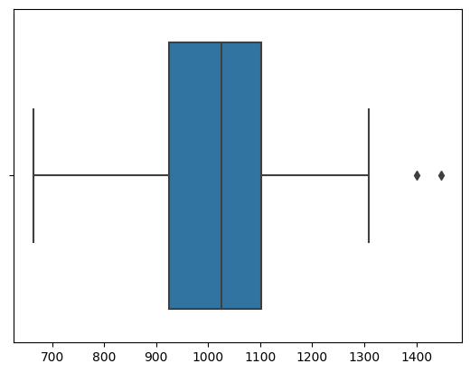

```python
sns.boxplot(x=measures)
```

And we can manipulate the underlying plot to control different features. See https://stackoverflow.com/questions/34162443/why-do-many-examples-use-fig-ax-plt-subplots-in-matplotlib-pyplot-python#34162641 and https://matplotlib.org/api/pyplot_api.html#matplotlib.pyplot.subplots for explanations about `plt.subplots()`

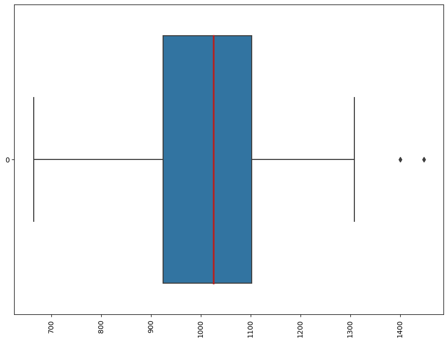

```python
fig, ax = plt.subplots()
fig.set_size_inches(11, 8)
medianprops = dict(linewidth=2.5, color='firebrick')
sns.boxplot(medianprops=medianprops, data=measures, orient='h')
_ = plt.xticks(rotation=90)
```

## Histogram

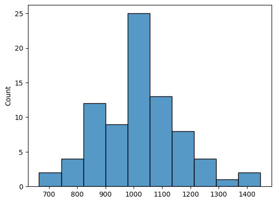

```python
# x axis = value, y axis = count (frequency)
sns.histplot(measures, kde=False)
```

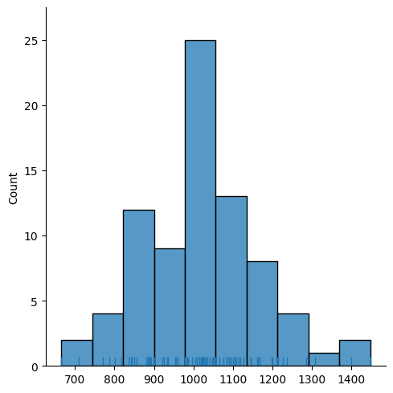

```python
# note use of displot rather than histplot
sns.displot(measures, rug=True); # show a strip plot on bottom -- we call it a "rug"
```

## Visualizing the menu data using Seaborn

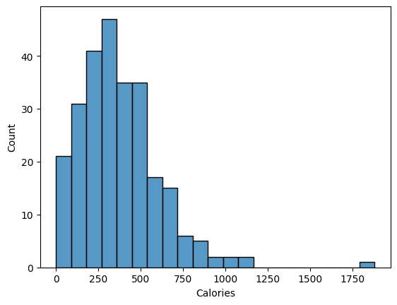

```python
sns.histplot(menu.Calories)
```

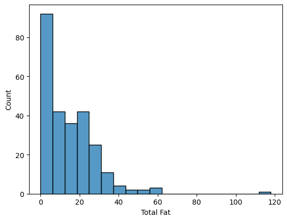

```python
sns.histplot(menu['Total Fat'])
```

[figure not shown]

```python
# Relationship between total fat and calories
sns.relplot(x="Calories", y="Total Fat", #hue="Category",
            sizes=(40, 400), alpha=.5,
            height=6, data=menu)
```

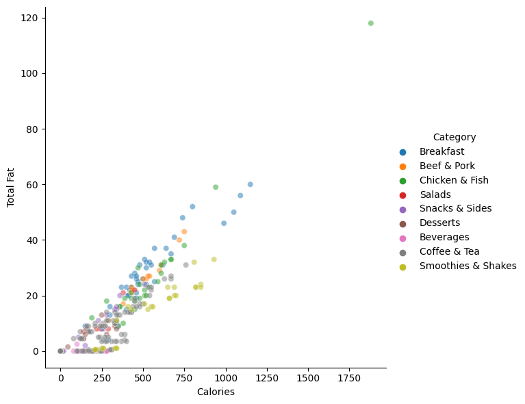

```python
# Relationship between total fat and calories
sns.relplot(x="Calories", y="Total Fat", hue="Category",
            sizes=(40, 400), alpha=.5,
            height=6, data=menu)
```

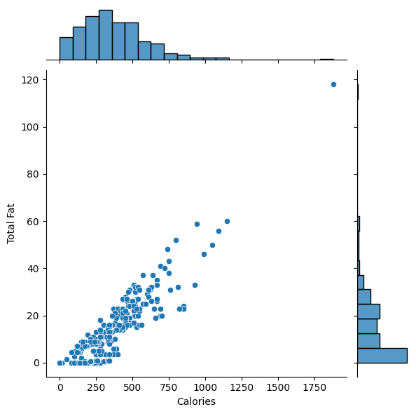

```python
sns.jointplot(x='Calories', y='Total Fat', data=menu)
```

It's a bit difficult to see where the interesting areas in the plot are, so it's worth trying a hexbin plot. Go ahead and copy the above code block and add `kind="hex"` to the jointplot parameters.

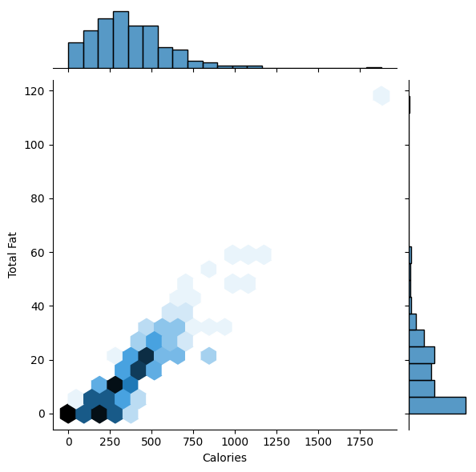

```python
sns.jointplot(x='Calories', y='Total Fat', data=menu, kind='hex')
```

Finally, you may want to look at all the numeric variables in your dataset. Use `pairplot` to do this:

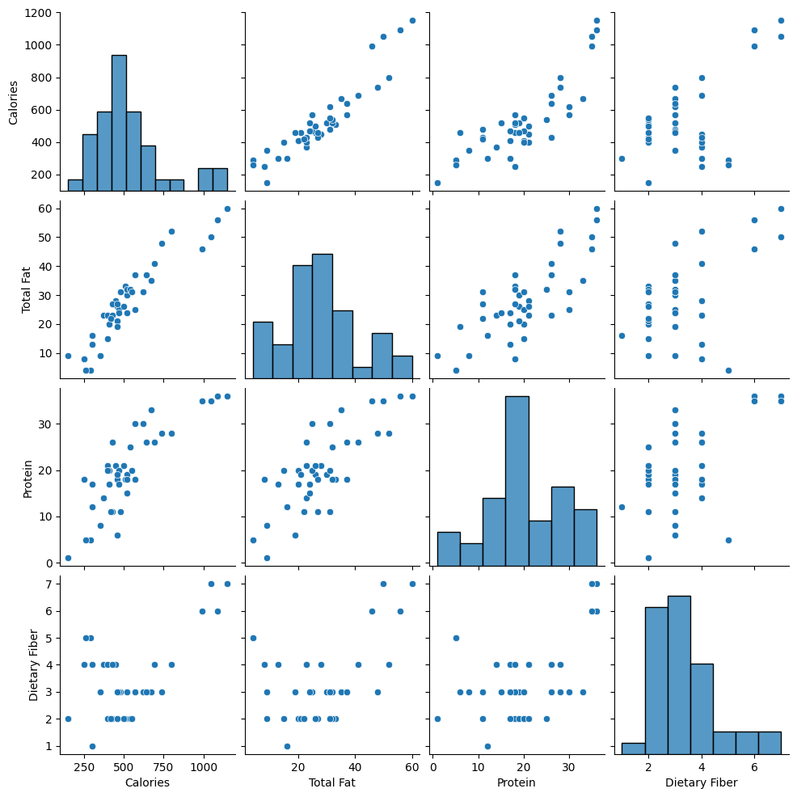

```python
sns.pairplot(menu.query("Category == 'Breakfast'"),
             vars=['Calories', 'Total Fat', 'Protein', 'Dietary Fiber'])
```

We can get fancier by using a different column to set the color (or "hue"):

Try running the following code:

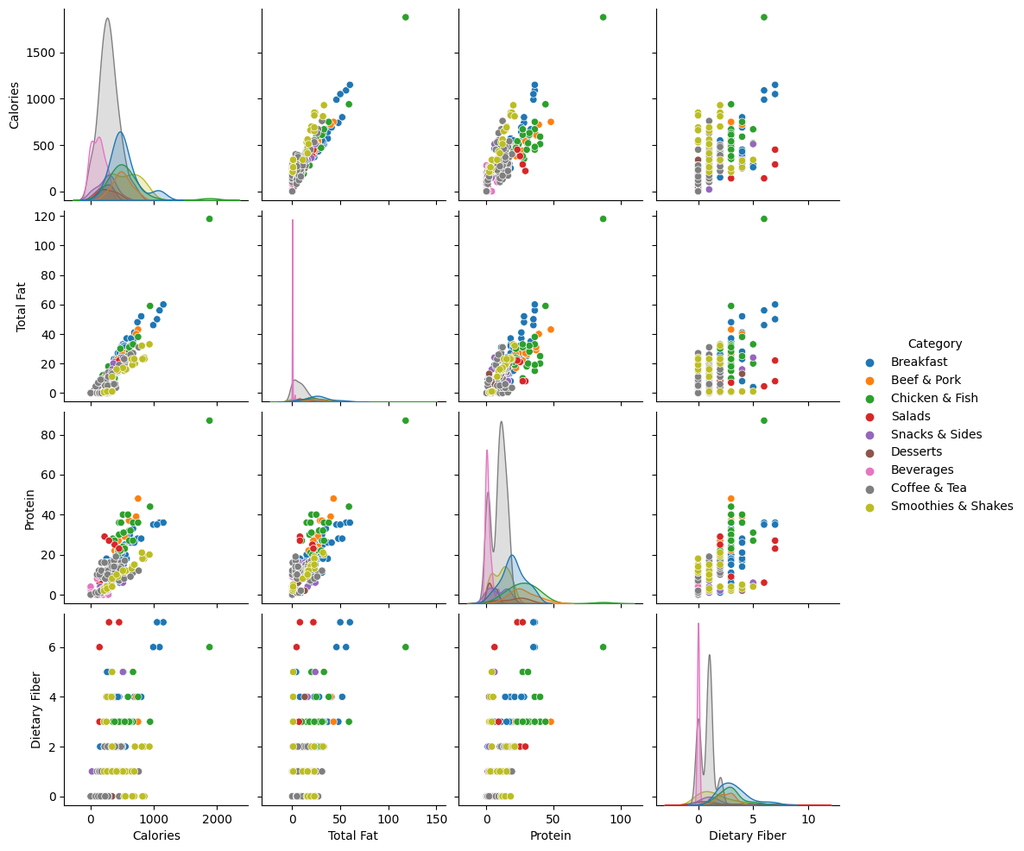

```python
sns.pairplot(data=menu,
             hue="Category",
             vars=['Calories', 'Total Fat', 'Protein', 'Dietary Fiber'])
```

## Why do we care about distributions?

## World is not normal

- Many other kinds of distributions
- We can tell what they are by looking at distribution

## Uniform

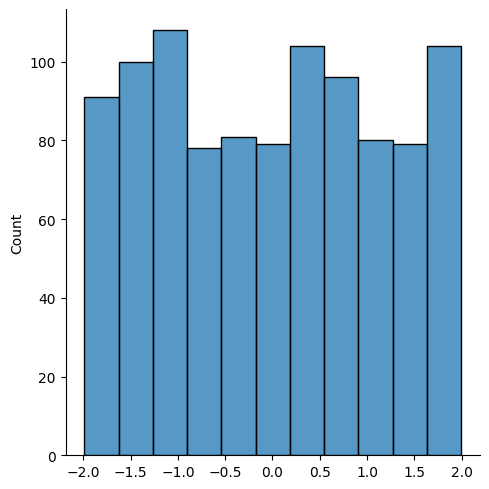

```python
uniform = np.random.uniform(-2, 2, 1000)  # low,high,count
sns.displot(uniform, kde=False)
```

## Bimodal

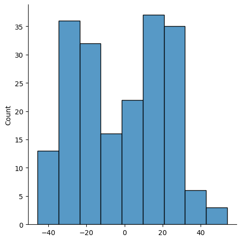

```python
bimodal = np.append(np.random.normal(-20, 10, 100),
                    np.random.normal(20, 10, 100))
sns.displot(bimodal)
```

# Poisson

$$ P(k~events~in~interval) = \frac{\lambda^ke^{-\lambda}}{k!} $$

$\lambda$ is the event rate

Examples

- Meteor strikes
- Arrival of patients to hospital

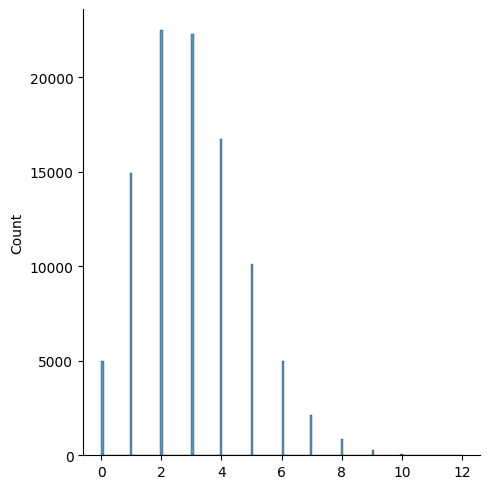

```python
# as lambda goes up --> looks more normal
pois = np.random.poisson(3, 100000) # lambda, count
sns.displot(pois)
```

# Power/Zipf/Pareto

$$ P = \frac{x^{-a}}{\zeta(a)}$$

"long tail"

- degree distribution
- movie/music popularity
- words

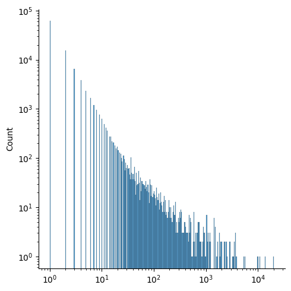

```python
power = np.random.zipf(2, 100000)
sns.displot(power, log_scale=(True, True))
```

## Visual Tests on Data

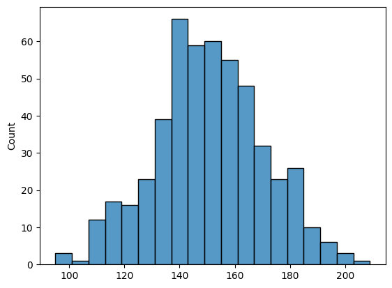

```python
testdata = (np.random.standard_normal(500)*20+150).astype(int)
sns.histplot(testdata)
```

## Run Sequence

- Run Sequence (index versus value)
- flat and non-drifting
- fixed-location assumption holds
- vertical spread same over the entire plot,
- then the fixed-variation assumption holds.

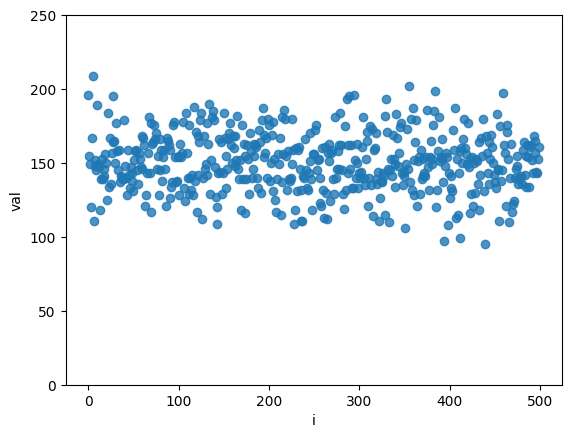

```python
ax = sns.regplot(x=np.arange(len(testdata)), y=testdata, fit_reg=False)
ax.set_ylim(0, 250)
ax.set_ylabel("val")
ax.set_xlabel("i")
```

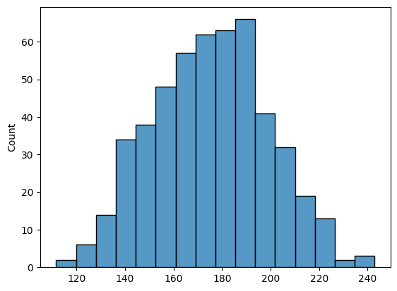

```python
drifting = np.array([testdata[i]+i*(.1) for i in np.arange(len(testdata))])
sns.histplot(data=drifting, kde=False)
```

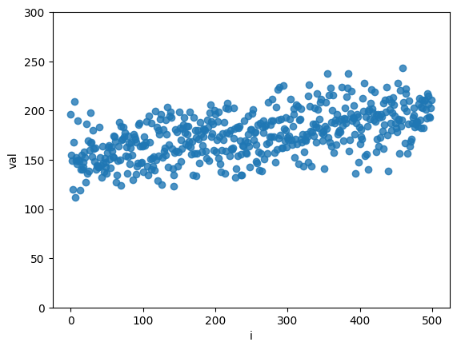

```python
ax = sns.regplot(x=np.arange(len(drifting)), y=drifting, fit_reg=False)
ax.set_ylim(0, 300)
ax.set_ylabel("val")
ax.set_xlabel("i")
```

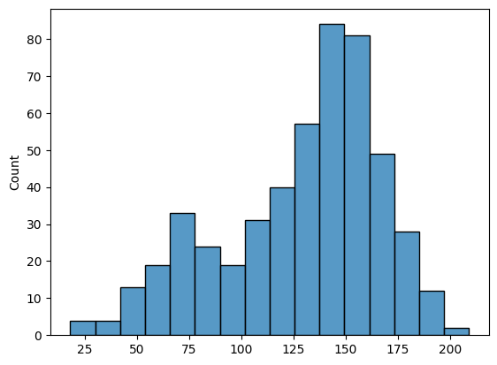

```python
expanding = np.array([(testdata[i]+i*np.random.randint(-1,1)*.2)
                     for i in np.arange(len(testdata))])
sns.histplot(expanding)
```

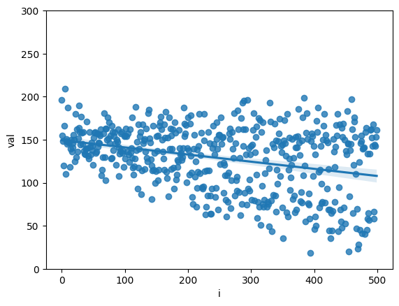

```python
ax = sns.regplot(x=np.arange(len(expanding)), y=expanding)
ax.set_ylim(0, 300)
ax.set_ylabel("val")
ax.set_xlabel("i")
```

# Lag Plot

- Plot point $y_i$ versus $y_{i-1}$
- If the lag plot is structureless
- randomness assumption holds.

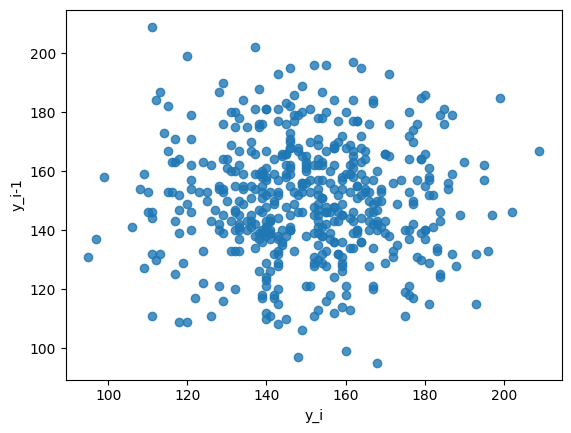

```python
lag = testdata.copy()
lag = np.array(lag[:-1])
current = testdata[1:]
ax = sns.regplot(x=current, y=lag, fit_reg=False)
ax.set_ylabel("y_i-1")
ax.set_xlabel("y_i")
```

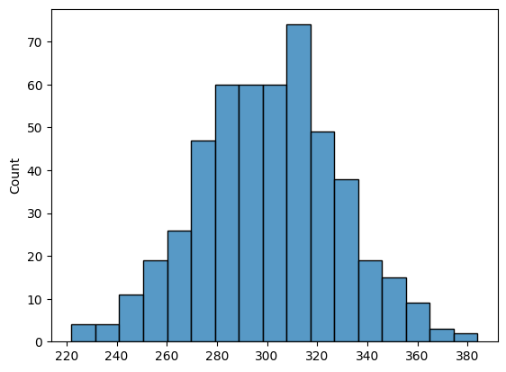

```python
connected = np.array([testdata[i]+testdata[i-1] for i in np.arange(500)])
sns.histplot(connected)
```

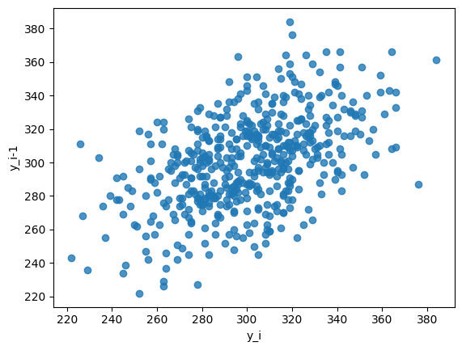

```python
lag = connected.copy()
lag = np.array(lag[:-1])
current = connected[1:]
ax = sns.regplot(x=current, y=lag, fit_reg=False)
ax.set_ylabel("y_i-1")
ax.set_xlabel("y_i")
```

## QQ Plot

- QQ Plots takes our n ordered data points
- sorted from smallest to largest
- Asks:
- What is the relationship between quantiles from our data and quantiles from a theoretical distribution that we're assuming the sample is drawn from

```python
from scipy import stats
```

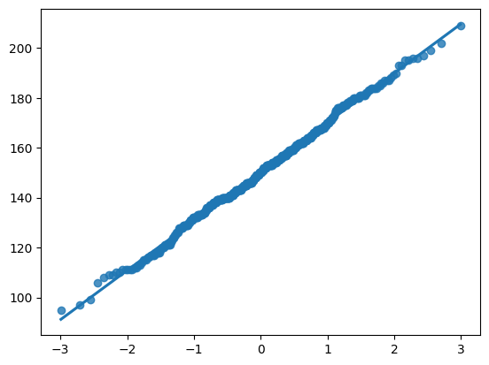

```python
qntls, xr = stats.probplot(testdata, fit=False)
sns.regplot(y=xr, x=qntls)
```

```python
def random_snorm(n, mean = 0, sd = 1, xi = 1.5):
    def random_snorm_aux(n, xi):
        weight = xi/(xi + 1/xi)
        z = np.random.uniform(-weight,1-weight,n)
        xi_ = xi**np.sign(z)
        random = -np.absolute(np.random.normal(0,1,n))/xi_ * np.sign(z)
        m1 = 2/np.sqrt(2 * np.pi)
        mu = m1 * (xi - 1/xi)
        sigma = np.sqrt((1 - m1**2) * (xi**2 + 1/xi**2) + 2 * m1**2 - 1)
        return (random - mu)/sigma

    return random_snorm_aux(n, xi) * sd + mean
```

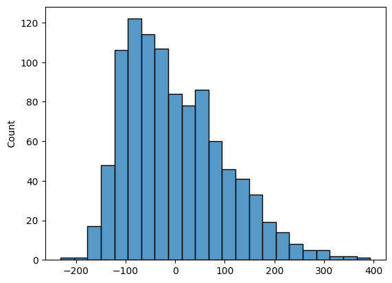

```python
rightskewed = random_snorm(1000, xi=2)*100
sns.histplot(rightskewed, kde=False)
```

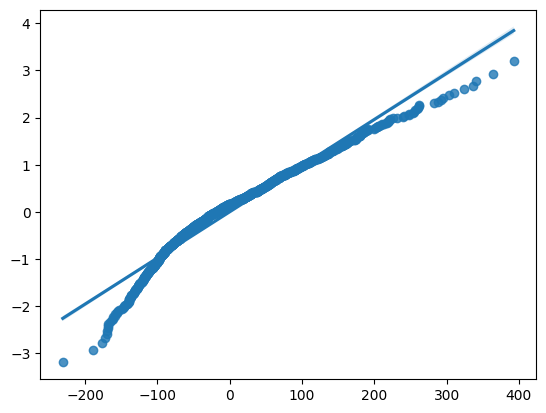

```python
qntls, xr = stats.probplot(rightskewed, fit=False)
sns.regplot(x=xr, y=qntls)
```

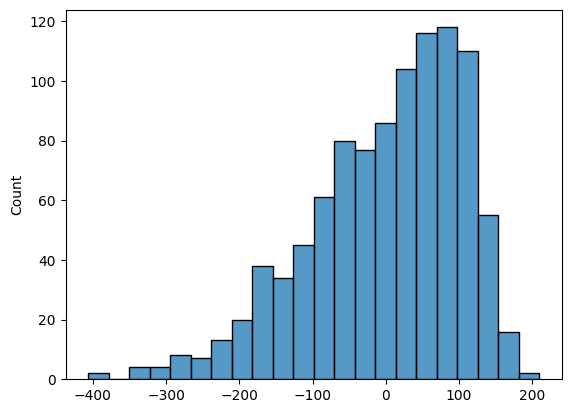

```python
leftskewed = random_snorm(1000, xi=-2)*100
sns.histplot(leftskewed, kde=False)
```

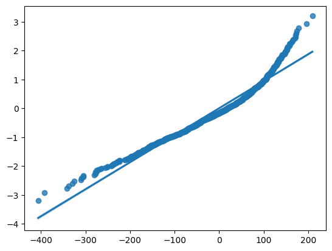

```python
qntls, xr = stats.probplot(leftskewed, fit=False)
sns.regplot(x=xr, y=qntls)
```

## Now the serious plots... let's wrap them in a single function that we can call

```python
import matplotlib.pyplot as plt
import seaborn as sns
from scipy import stats
```

```python
def multiplePlots(series):

    fig, axs = plt.subplots(2, 2)
    plt.tight_layout(pad=0.4, w_pad=4, h_pad=1.0)

    # Histogram
    sns.histplot(series, ax=axs[0, 0])

    # Lag plot
    lag = series.copy()
    lag = np.array(lag[:-1])
    current = series[1:]
    ax = sns.regplot(x=current, y=lag, fit_reg=False, ax=axs[0, 1])
    ax.set_ylabel("y_i-1")
    ax.set_xlabel("y_i")

    # QQ plot (updated 2023.08.18.1.CT to match usual QQ plot -- axes flipped)
    qntls, xr = stats.probplot(series, fit=False)
    sns.regplot(y=xr, x=qntls, ax=axs[1, 0])

    # Run sequence
    ax = sns.regplot(x=np.arange(len(series)), y=series, ax=axs[1, 1])
    ax.set_ylabel("val")
    ax.set_xlabel("i")
```

## Now run this on `measures`

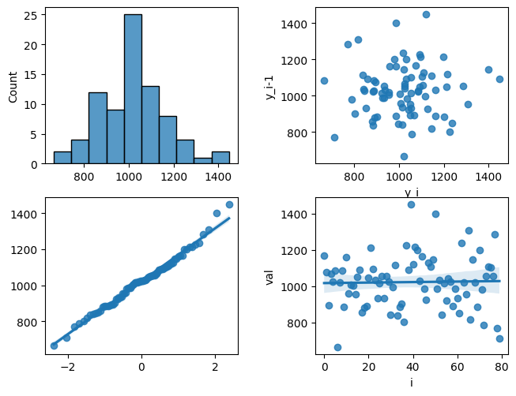

```python
multiplePlots(measures)
```

### Q12: [Do your data look](https://www.theguardian.com/news/datablog/2010/jul/16/data-plural-singular) normally distributed?

Yes, the histrogram looks noramlly distributed, there is no structure to the lagplot, the QQ plot points fall on the line, and the run sequence plot is flat and non-drifting

### Q13:

The sample.csv file, loaded for you in the next cell, contains 9 variables (v0 through v8) that contain measures drawn from different distributions. Your task is to use the investigative techniques we discussed in today's lab to determine what type of distribution the sample is drawn from.

You should first load the CSV file into a DataFrame, then look at various aspects of **each** variable.

**Your responses should consist of code cells, as well as markdown cells that state something like:**

> Variable v99 appears to be drawn from a uniform distribution with mean X and standard deviation Y.  
> A histogram of the data appears to be... The QQ plot shows....

Note: try not to repeat your code. You can use loops, functions, etc. to avoid repeating yourself. (remember, [DRY](https://en.wikipedia.org/wiki/Don%27t_repeat_yourself)).

```python
distributions = pd.read_csv('https://raw.githubusercontent.com/umsi-data-science/data/main/sample.csv')
```

```python
distributions.columns
```

```
Index(['Unnamed: 0', 'v0', 'v1', 'v2', 'v3', 'v4', 'v5', 'v6', 'v7', 'v8'], dtype='object')
```

## V0

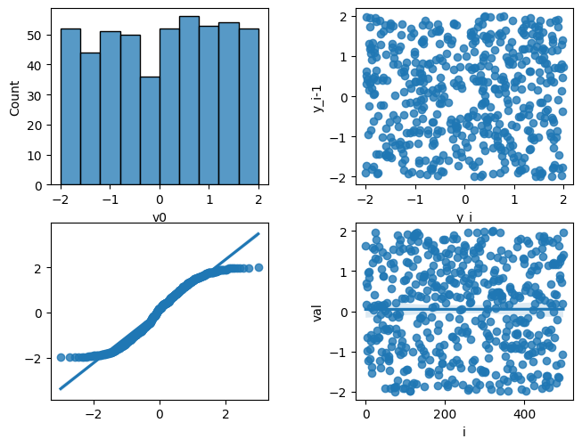

```python
multiplePlots(distributions['v0'])
```

The distribution of v0 appears to be drawn from a uniform distribution. This is because the histogram is flat, the QQ plot is an S, the lag plot is structureless, and the run sequence plot is flat and non-drifting

## v1

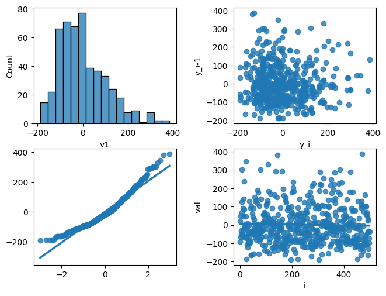

```python
multiplePlots(distributions['v1'])
```

The data in v1 appears to be drawn from a right skewed normal distribution. This is because the histogram is right skewed, the QQ plot ends point upwards, the lag plot is strctured to the bottom left, and the run plot is flat but drifted.

## v2

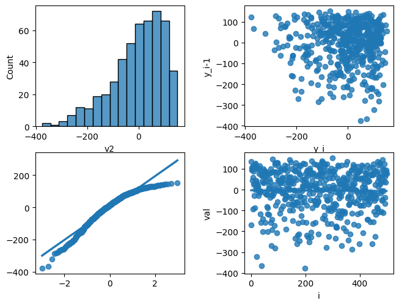

```python
multiplePlots(distributions['v2'])
```

The data in v2 appears to be drawn from a left skewed normal distribution. This is because the histogram is left skewed, the QQ plot ends point downward, the lag plot is strctured to the top right, and the run plot is flat but drifted.

## v3

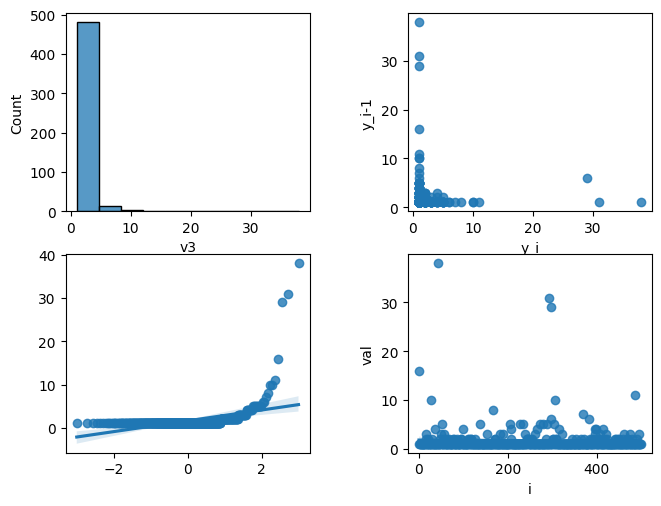

```python
multiplePlots(distributions['v3'])
```

## v4

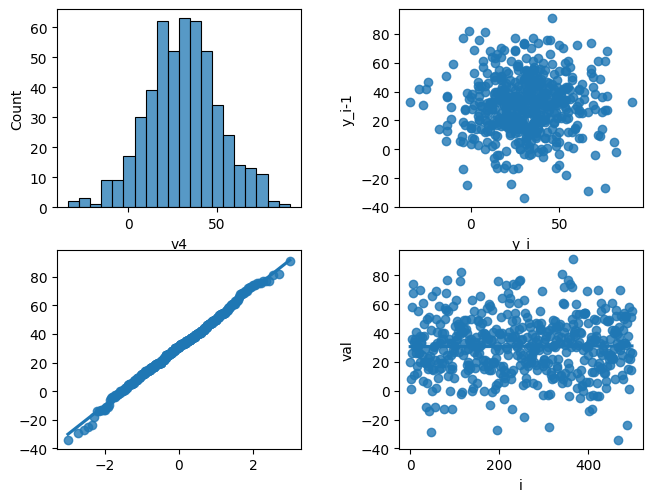

```python
multiplePlots(distributions['v4'])
```

The data for variable v4 appears to be drawn from a normal distribution. The histogram is normal, the lag plot is structureless, the QQ plot points fall on the line, and the run graph is flat and non-drifting.

# v5

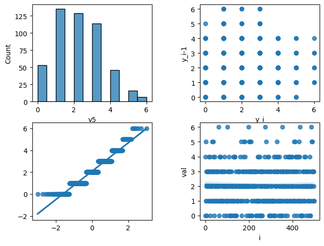

```python
multiplePlots(distributions['v5'])
```

# v6

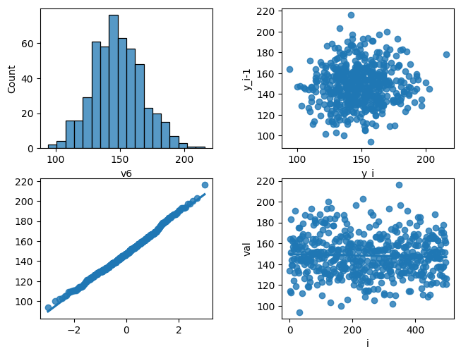

```python
multiplePlots(distributions['v6'])
```

The data for v6 appears to be drawn from a normal distribution. The histogram is normal, the lag plot is structureless, the QQ plot points fall on the line, and the run graph is flat and non-drifting.

# v7

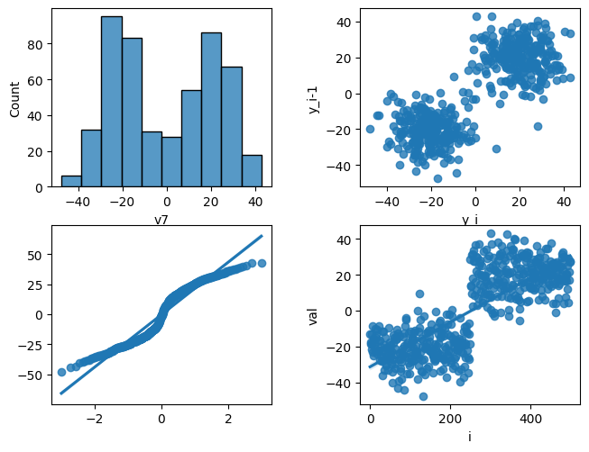

```python
multiplePlots(distributions['v7'])
```

The data in v7 appears to be drawn from a bimodal distribution. We can see the two peaks in the histogram, the QQ plot is an S, and the run plot and lag plot are both forming two distinct structures.

# v8

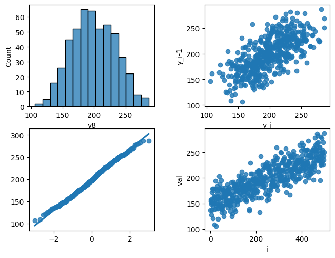

```python
multiplePlots(distributions['v8'])
```

Not Normal the lag and run plots are structure and drifting.

## Remember to submit your notebook in .ipynb and .html formats via Canvas